# ReproRes Poll Class 02

[figure not shown]

[figure not shown]

[figure not shown]

[figure not shown]

[figure not shown]

[figure not shown]

[figure not shown]

35 Participants

### How did you engage with Chapter 2?

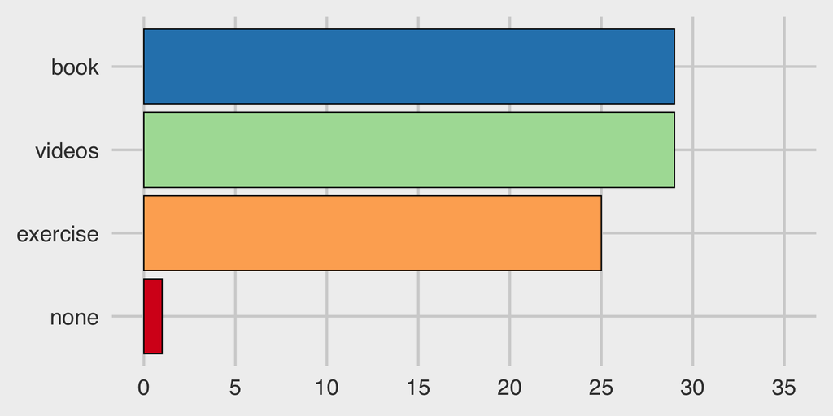

### What parts of Skills Self-Assessment did you find challenging or impossible?

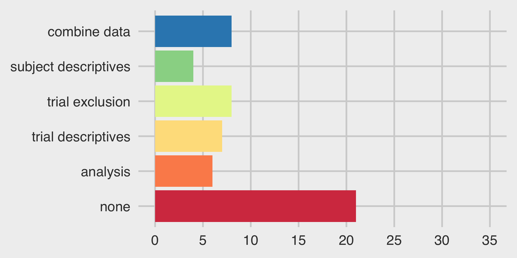

### How did you engage with the Skills Self-Assessment?

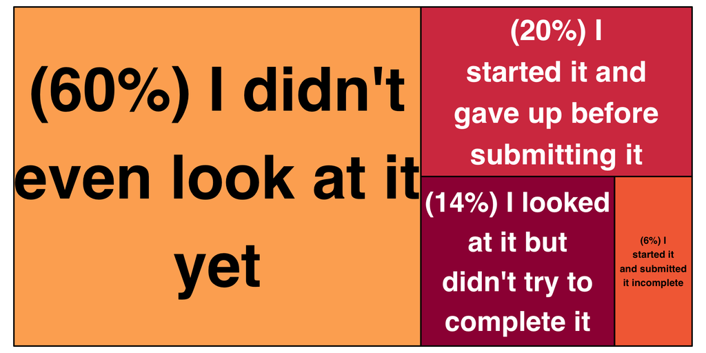

### How are you accessing RStudio?

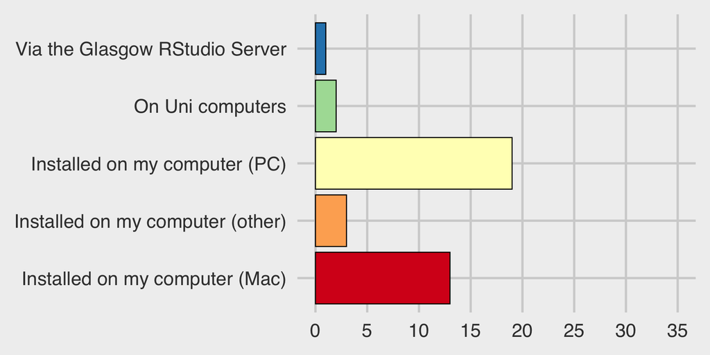

### Have you been studying in a group?

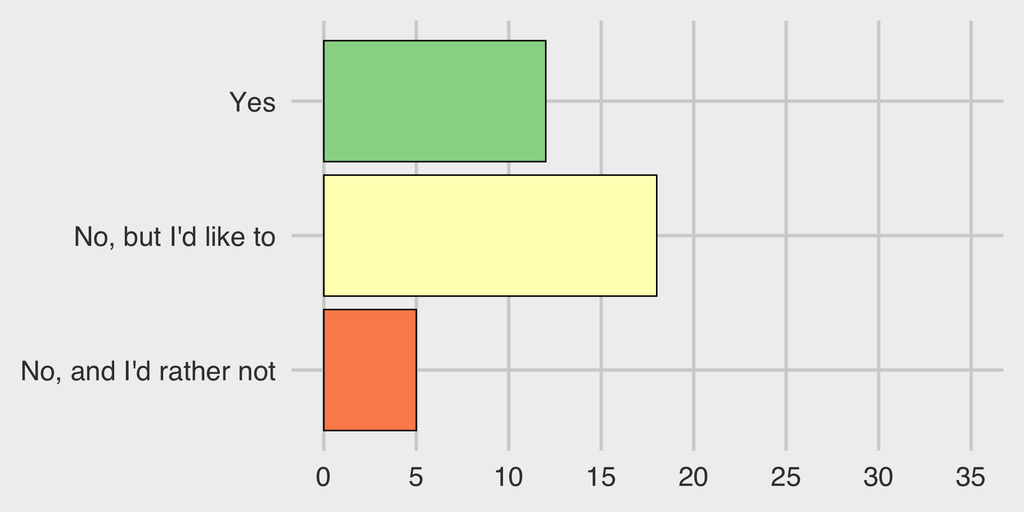

### List concepts you learned in Chapters 1 and 2 that you feel confident about.

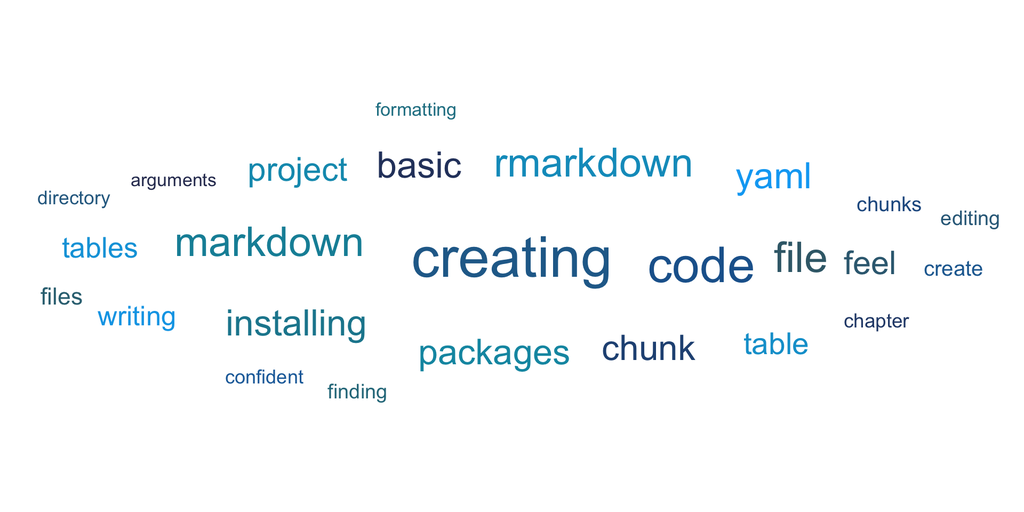

### List concepts you learned in Chapters 1 and 2 that you feel less confident about and would like reviewed in class today.

[figure not shown]

### Confident

formatting project, finding helper, writing code

installing packages and running them, variables, c(), making a table

formatting r markdown, arguments, and utilizing the environment.

doing basic r syntax; writing in an r markdown file; creating a new project and r markdown file.

some code for calculation

Creating a VERY basic table, installing & loading packages

hardly anything

yes

Differentiating between functions, arguments, objects; finding and creating datasets.

1. importing data and organising/sorting it.
2. Starting scripts and Rmarkdown files
3. knowing what all the different symbols mean and how to use them.
4. The value of producing reproducible reports.
5. How to properly name files so they are well organised and useable.
6. Setting and working from directories.
7. How to produce a bibliography from a reference manager.
8. creating headings and subheadings.
9. creating bold and/or italic text
10. creating code chunks using backticks
11. how to make a code chunk be visible in the Rmarkdown file but not in the knitted output
12. how to create a basic table
13. how to include an image from a html link
14. how to create clickable hyperlinks in the knitted file

installing packages, knowing methods for help, creating an Rmarkdown document, editing the YAML header, including tables and pictures,

I feel pretty comfortable with all content so far

Everything- I have extensively done R before so this is revision for me

Loading and Installing Packages Basic Arithmatic

I understand how to make a code chunk and that’s basically the only thing I feel confident about.

No comment

I feel quite confident with most of the other topics covered

using the function library, install_packages, using the r chunk

creating projects and rmarkdowns, editing the yaml header, writing inline

open R studio

start a R project

Creating a project, using functions, using RMarkdown

Markdown, tables

RMarkdown

All of chapter 1. Chapter 2 - Rmarkdown, working directory, YAML, setup, structure, code chunks, tables, images

installing packages, listing, setting directory

knit, r markdown, yaml, chunk

knit, r markdown

### Not Confident

adding images to rmarkdown

linking an image, Kable function/ using Kable for the yaml header

creating tables in R markdown

making tables, adding bibliography to Rmarkdown, getting the toc to appear on Rmarkdown, i am confused about what fortunes is and the dplyr package has an error message when I try to install/load it

how to knit a table; how to use downloaded themes from bootstrap

Editing YAML header, in-line R, using kable

markdown

Adding images, links and new data. Creating lists (e.g., bullet point lists)

struggled inserting an image struggled with the table my markdown wouldnt knit to html struggled changing the theme

yes

Citations & bibliography; YAML header personalisation & how to lay out the different options within the YAML header.

1. how to include an image from a file already on your computer
2. how to alter table code to make them more aesthetically pleasing
3. how to simulate data

reporting output of analysis using in-line R, adding bibliography and citations

n/a, although am a bit rusty with adding images to r studio

Nothing

Tables and Polls General Terminology

I onlu understood about the first half of chapter 2, and then could not figure out how to translate those skills to the exercise

No comment

Inserting images into RMarkdown and formatting them on the page

The rest with r markdown: making a table, compiling what I learnt from the videos and book into application

a code chunk

change the table style

YAML headers

bibliography, linked documents

kable, headers, in-line R, inserting images, tables. most of chapter 2

tables, image & figures

Making tables, inserting images, figures